# slide_deck_fordgobike_data_analysis slides

### DATA VISUALISATION AND INTERPRETATION FOR FORD GO BIKE DATA

**By Ifeoma Onyiuke**

### INTRODUCTION

For this project I choose to analyse and plot visualisations for the Ford go bike dataset for 2018. This dataset was provided by Udacity and downloaded manually from the resource centre as a `.CSV` file.. This data set includes information about individual rides made in a bike-sharing system covering in the greater San Francisco Bay area.

duration_sec| start_time|end_time|start_station_id| start_station_name|start_station_latitude|start_station_longitude |end_station_id|end_station_name|end_station_latitude|end_station_longitude|bike_id|user_type|member_birth_year|member_gender

The first step was to carry out Data Wrangling processes on the data to ensure it meets the requirements for Quality and Tidy Data. In the data wrangling phase a lot exploration was carried to get deeper insights on what the data looks like.

In the second phase "Explanatory Phase" Various plots from "Univaraite to Multivariate" were created to give and share the insights observed in the first phase.

A slide will be prepared in conclusion to share the outcome. Target is to share finding with audience or users and ensure they get a deep understanding of the data as much as possible.

### Perentage distribution of Riders

75% of riders are male, according to an article I found on the internet it is expected because females are more concerned about their safety than male and also the possibility of cycling smudging their makeup or messing up their hair, females tend to avoid this means of transportation.

[figure not shown]

```python
#set order for chart
sorted_counts.index = ['Male', 'Female', 'Others']
plt.pie(sorted_counts, labels = sorted_counts.index, startangle = 90, counterclock=False, autopct='%1.0f%%', pctdistance=1.1, labeldistance=1.22, wedgeprops={'width':0.4});
plt.axis('square');
plt.title("Distribution of Riders by Day of the Week", fontsize=12, weight='bold', y=1.1)
plt.xlabel('Day of Week', fontsize=12, weight='bold')
plt.ylabel('Count', fontsize=12, weight='bold');
```

### Count for riders for each day of week

It is possible that some of the users that rent these bikes take them home, because calculating from the start and end time and also duration it appears to be in possession of some users for more than one day.

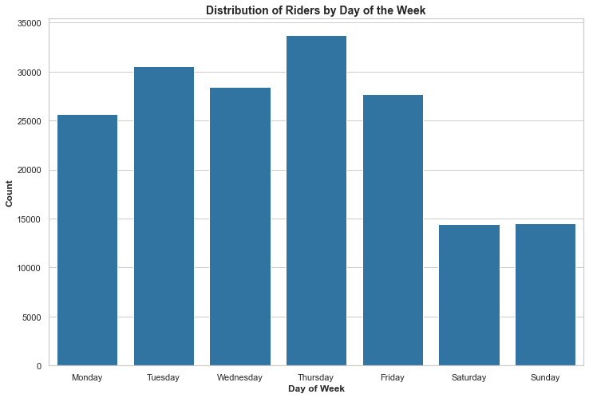

```python
#set color
base_color = sns.color_palette()[0]
#set plot dimension
plt.figure(figsize=[12, 8])
#list of categories
day_order = ['Monday', 'Tuesday', 'Wednesday', 'Thursday', 'Friday', 'Saturday', 'Sunday']
sns.countplot(data=bike_data_clean, x='start_day_of_week', color=base_color, order=day_order)
#add title
plt.title("Distribution of Riders by Day of the Week", fontsize=14, weight='bold')
plt.xlabel('Day of Week', fontsize=12, weight='bold')
plt.ylabel('Count', fontsize=12, weight='bold');
```

Thursday has the highest number of usage. There is very low usage during weekends. the peak on thursday could be due to traffic or demand for individuals to get to the train station to catch a train for the weekend. Exploring the time of this peak can give more insights

### Trip Count for Take-off and Arrival Stations

Count of total trips from take-off to arrival stations indicates that the take-off station with the highest number of counts is Market St at 10th St and the San Francisco Caltran station has the highest number of arrivals.

- The Caltran bike station is very close the San Francisco train station. * It makes sense that it has a highest number of stop location for the users.
- The Market St is within a commercial zone and lots of activities happening around this area. It is expected to have high number of users as well.

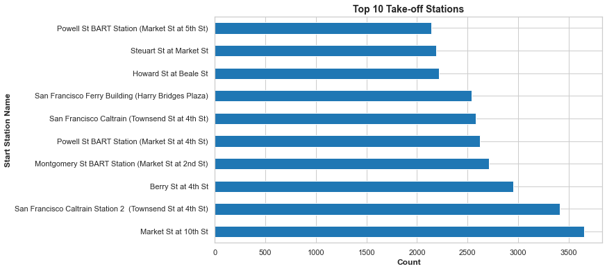

```python
#plot to see the top 10 take off stations
#set plot dimension and color
base_color = sns.color_palette()[0]
plt.figure(figsize=[10, 6])
top10_start_stations = expl_bike_data.start_station_name.value_counts()[0:10]
#sns.countplot(data=top10_start_stations, y='start_station_name', color=base_color)
plt.xlabel('Count', fontsize=12, weight='bold')
plt.ylabel('Start Station Name', fontsize=12, weight='bold')
plt.title('Top 10 Take-off Stations', fontsize=14, weight='bold')
#plot locations
top10_start_stations.plot(kind='barh', color=base_color);
```

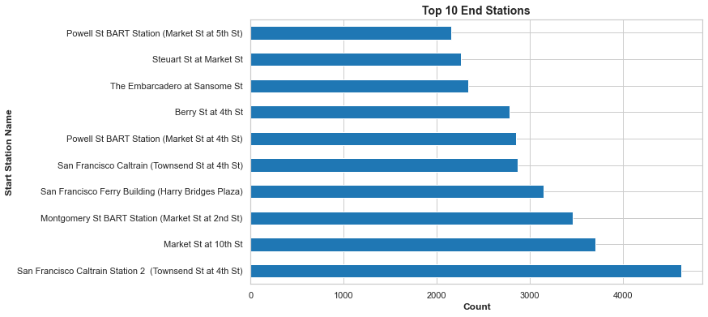

```python
#plot to see the top 10 take off stations
#set dimensions
base_color = sns.color_palette()[0]
plt.figure(figsize=[10, 6])
#sort stations by count
top10_start_stations = expl_bike_data.end_station_name.value_counts()[0:10]
#sns.countplot(data=top10_start_stations, y='start_station_name', color=base_color)
plt.xlabel('Count', fontsize=12, weight='bold')
plt.ylabel('Start Station Name', fontsize=12, weight='bold')
plt.title('Top 10 End Stations', fontsize=14, weight='bold')
#plot locations
top10_start_stations.plot(kind='barh', color=base_color);
```

### Comparing the age distribution with the gender of the riders

- The KDE plot shows obviously that within the various age range, the number of males are more than the female.
- The box plot looks better as it clearly shows the median age for riders. The data seems dispersed due to the wideness of the box. It looks symmetrical but a little skewed to the right as moset of the data falls within the age range of `<40years`.
- For the violinplot, the probability of the mean age being a male or female or other is almost at the same range. But the weight for the age being a female seems higher.

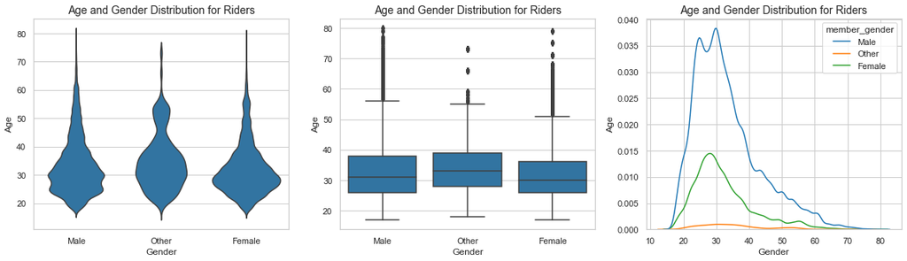

```python
plt.figure(figsize = [20, 5])
base_color = sns.color_palette()[0]

#left plot: violinplot
plt.subplot(1, 3, 1)
sns.violinplot(data=expl_bike_data, x='member_gender', y='member_age', inner=None, color=base_color);
plt.title("Age and Gender Distribution for Riders", fontsize=14)
plt.xlabel("Gender", size=12)
plt.ylabel("Age", size=12);

#centerplot: boxplot
plt.subplot(1, 3, 2)
sns.boxplot(y='member_age', x='member_gender', data=expl_bike_data, color=base_color);
plt.title("Age and Gender Distribution for Riders", fontsize=14)
plt.xlabel("Gender", size=12)
plt.ylabel("Age", size=12);

#rightplot: KDEplot
plt.subplot(1, 3, 3)
sns.kdeplot(data=expl_bike_data, x='member_age', hue='member_gender', color=base_color);
plt.title("Age and Gender Distribution for Riders", fontsize=14)
plt.xlabel("Gender", size=12)
plt.ylabel("Age", size=12);
```

### Average distance travelled on each day of the week by each gender

The Distance travelled seems relative across each gender. The only spike notied in this data was a trip on of Approximately 64km made on Tuesday by a Female. The mean for each trip distance is about `1.5km`

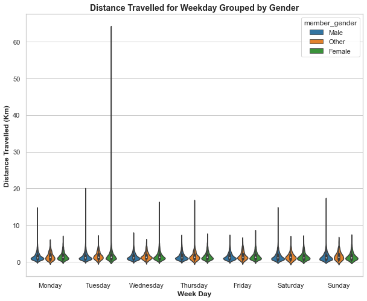

```python
#Plot the distance travelled each day of the week and group by gender of the rider
#base_color = sns.color_palette()[0]
sns.set(style="whitegrid", palette="tab10", color_codes=False)
#set dimensions
f, ax = plt.subplots(figsize=(10, 8))
#set order for day of week
day_order = ['Monday', 'Tuesday', 'Wednesday', 'Thursday', 'Friday', 'Saturday', 'Sunday']
#Mulitvariate plot
sns.violinplot(data=expl_bike_data, x='start_day_of_week', y='distance', hue='member_gender', order=day_order);
#set plot labels
plt.title("Distance Travelled for Weekday Grouped by Gender", fontsize=14, weight='bold')
plt.xlabel("Week Day", size=12, weight='bold')
plt.ylabel("Distance Travelled (Km)", size=12, weight='bold');
```

### Mean Age for Riders

**A plot for the mean age for riders, comparing the riders and user type,** shows that the **mean age** across all genders is between **31 and 35 years**. Although some of the riders were above 60years, this is still a clear indicator that the market should target young people within the age range of **17 and 40years** as they have the highest use rate for this services.

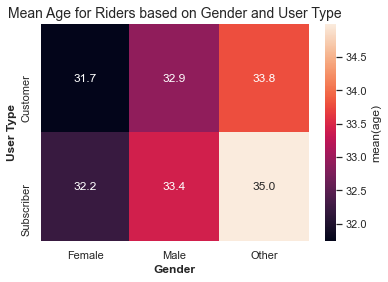

```python
#Mean age for riders based on Gender and user type
cat_means=expl_bike_data.groupby(['member_gender','user_type']).mean()['member_age']
cat_means = cat_means.reset_index(name = 'age_avg')
cat_means = cat_means.pivot(index = 'user_type', columns = 'member_gender',
                            values = 'age_avg')
sns.heatmap(cat_means, annot = True, fmt = '.1f',
           cbar_kws = {'label' : 'mean(age)'});
plt.title("Mean Age for Riders based on Gender and User Type", fontsize=14)
plt.xlabel("Gender", size=12, weight='bold')
plt.ylabel("User Type", size=12, weight='bold');
```

### RESOURCES

- https://www.counterpointresearch.com/understanding-fords-gobike-user-dynamic/
- https://www.geeksforgeeks.org/selecting-rows-in-pandas-dataframe-based-on-conditions/
- https://gist.github.com/rochacbruno/2883505